[figure not shown]

# Data Analysis

### Andrey Shestakov (avshestakov@hse.ru)

## Metric-based models<sup>1</sup>

### Nearest Centroid, K-NN

<sup>1. Some materials are taken from machine learning course of Victor Kitov</sup>

# Let's recall previous lecture

- Machine learning algorithms reconstruct relationship between features $x$ and outputs $y$.
- Design matrix $X=[\mathbf{x}_{1},...\mathbf{x}_{M}]^{T}$, $Y=[y_{1},...y_{M}]^{T}$.
- Relationship is reconstructed by optimal function $\widehat{y}=f_{\widehat{\theta}}(x)$ from function class $\{f_{\theta}(x),\,\theta\in\Theta\}$.
- Empirical risk appriximation
  - Hold-out validation
  - Cross-validation
  - A/B testing
- Given classes $c=1,2,...C$ we may consider *discriminant function* $g_{c}(x)$ - score of class $c$, given $x$
  - Classification: $\widehat{y}=f(x|\theta)=\arg\max_{c}\left\{ g_{c}(x|\theta)\right\}$

# Metric-based models

# Cluster hypothesis (Compactness hypothesis)

- the more $x$'s features are similar to ones of $x_i$'s, the more likely $\hat{y}=y_i$

## Cluster hypothesis examples

[figure not shown]

- Objects: Families, households
- Featuers: address, zip code, nearest marketplace... $\rightarrow$ geo-coordinates `(lat, lon)`
- Target feature: race (classification)

## Cluster hypothesis examples

[figure not shown]

- Objects: Houses
- Features: address... $\rightarrow$ geo-coordinates `(lat, lon)`
- Target feature: house price (regression)

[figure not shown]

- Objects: DNA strings
- Features: ??
- Target features: Gene function (classification)

[figure not shown]

- Objects: Documents, texts, articles
- Features: Word counts
- Target: Document category (classification)

# Similarity (distance) measures

## Similarity measures

- How do we find similar objects?
- Utilize some similiarity measure (could be metric)

### Most popular are

$$ \rho(x_i, x_j) = \sum\limits_{d=1}^{D}(x^d_i - x^d_j)^2 \text{: euclidean distance} $$

$$ \rho(x_i, x_j) = \sum\limits_{d=1}^{D}|x^d_i - x^d_j| \text{: manhattan distance} $$

$$ \rho(x_i, x_j) = 1 - \frac{\langle x_i,x_j \rangle}{||x_i||_2\cdot||x_j||_2} \text{: cosine distance} $$

### String Similarity

- Edit distance
  - Number of insertions, replacements and deletions required to modify string $S_1$ to string $S_2$
- Denote $D( i , j )$ as edit distance between substrings $S_1[:i]$ and $S_2[:j]$.
- Use dynamic programming approach to compute $\rho(S_1, S_2):$

\begin{equation} D ( i , j ) = \begin{cases} {\begin{array}{llcl}0,&&&i=0,\ j=0\\i,&&&j=0,\ i>0\\j,&&&i=0,\ j>0\\\min\{\\&D(i,j-1)+1,\\&D(i-1,j)+1,&&j>0,\ i>0\\&D(i-1,j-1)+{\rm {m}}(S_{1}[i],S_{2}[j])\\\}\end{array}}, \end{cases} \end{equation} where $m(a,b) = 0$, if $a = b$ and $1$ otherwise

- [Jaro–Winkler](https://en.wikipedia.org/wiki/Jaro%E2%80%93Winkler_distance) distance
- ...

## Edit distance example

[figure not shown]

### Similarity between sets

- Suppose thet objects are represented with sets
  - Client $a$: {french fries, big-mac, coffe, muffin}
  - Client $b$: {french fries, cheese sause, cheeseburger, coffe, cherry pie}
- Jaccard distance: $$\rho(a,b) = 1 - \frac{|a \cap b|}{|a \cup b|}$$

# Nearest Centroid

## Nearest centroids algorithm

- Consider training sample $\left(x_{1},y_{1}\right),...\left(x_{N},y_{N}\right)$ with
  - $N_{1}$ representatives of 1st class
  - $N_{2}$ representatives of 2nd class
  - etc.
- **Training:** Calculate centroids for each class $c=1,2,...C:$ $$ \mu_{c}=\frac{1}{N_{1}}\sum_{n=1}^{N}x_{n}\mathbb{I}[y_{n}=c] $$
- **Classification:**
  - For object $x$ find the most closest centroid: $$ c=\arg\min_{i}\rho(x,\mu_{i}) $$
  - Associate $x$ the class of the most close centroid: $$ \widehat{y}(x)=c $$

## Decision boundaries for 4-class nearest centroids}

```python
interact(plot_centroid_class)
```

```
<function __main__.plot_centroid_class>
```

## Questions

- What are discriminant functions $g_{c}(x)$ for nearest centroid?
- What is the complexity for:
  - training?
  - prediction?
- What would be the shape of class separating boundary?
- Can we use similar ideas for regression?
- Is it always possible to have centroids?

# K-nearest neighbours (KNN)

## K-nearest neighbours algorithm

**Classification:**

- Find $k$ closest objects to the predicted object $x$ in the training~set.
- Associate $x$ the most frequent class among its $k$ neighbours.

[figure not shown]

```
Text(0,0.5,u'$x_2$')
```

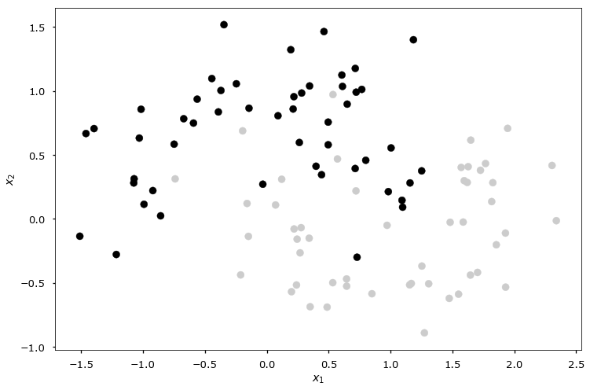

```python
plt.scatter(X_moons[:,0], X_moons[:,1], c=y_moons, cmap=plt.cm.spectral)
plt.xlabel('$x_1$')
plt.ylabel('$x_2$')
```

```python
interact(plot_knn_class, k=IntSlider(min=1, max=10, value=1))
```

```
<function __main__.plot_knn_class>
```

## K-nearest neighbours algorithm

**Regression:**

- Find $k$ closest objects to the predicted object $x$ in the training~set.
- Associate $x$ average output of its $k$ neighbours.

[figure not shown]

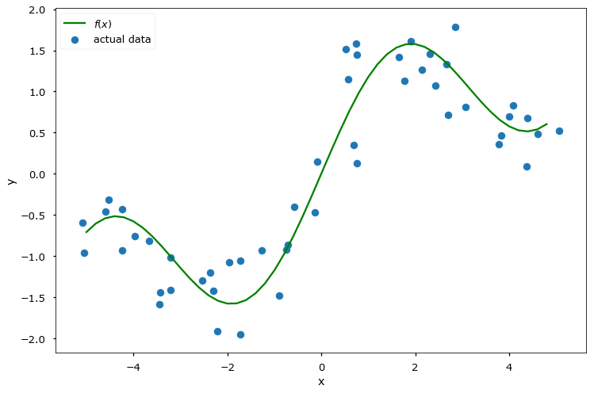

```python
plt.plot(x_true, y_true, c='g', label='$f(x)$')
plt.scatter(x, y, label='actual data')
plt.xlabel('x')
plt.ylabel('y')
plt.legend(loc=2)
```

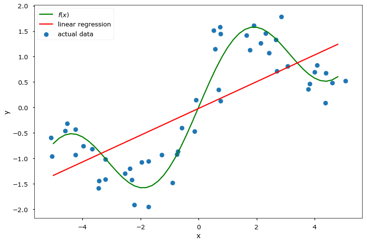

```python
plot_linreg()
```

```python
interact(plot_knn, k=IntSlider(min=1, max=10, value=1))
```

```
<function __main__.plot_knn>
```

## Comments

- K nearest neighbours algorithm is abbreviated as K-NN.
- $k=1$: nearest neighbour algorithm
- Base assumption of the method:
  - similar objects yield similar outputs
- *what is simpler - to train K-NN model or to apply it?*

## Dealing with similar rank

When several classes get the same rank, we can assign to class:

- with higher prior probability
- having closest representative
- having closest mean of representatives (among nearest neighbours)
- which is more compact, having nearest most distant representative

## Parameters and modifications

- **Parameters:**

```
* None
```

- **Hyperparameters**
  - the number of nearest neighbours $K$
  - distance metric $\rho(x,x')$
- **Modifications:**
  - forecast rejection option (propose a rule, under what conditions to apply rejection in a) classification b) regression)
  - variable $K$ (propose a method of K-NN with adaptive variable K in different parts of the feature space)

## Properties

- **Advantages:**
  - only similarity between objects is needed, not exact feature values.
    - so it may be applied to objects with arbitrary complex feature description
  - simple to implement
  - interpretable (kind of.. case based reasoning)
  - does not need training
    - may be applied in online scenarios
    - cross-validation may be replaced with LOO.
- **Disadvantages:**
  - slow classification with complexity $O(NDK)$
  - accuracy deteriorates with the increase of feature space dimensionality (curse of dimentionality)

# Special properties

## Normalization of features

- Feature scaling affects predictions of K-NN?

## Normalization of features

- Feature scaling affects predictions of K-NN?
  - sure it does! Need to normalize
- Equal scaling - equal impact of features
- Non-equal scaling - non-equal impact of features
- Typical normalizations:
  - z-scoring (autoscaling): $$x_{j}'=\frac{x_{j}-\mu_{j}}{\sigma_{j}}$$
  - range scaling: $$x_{j}'=\frac{x_{j}-L_{j}}{U_{j}-L_{j}}$$

where $\mu_{j},\,\sigma_{j},\,L_{j},\,U_{j}$ are mean value, standard deviation, minimum and maximum value of the $j$-th feature.

## The curse of dimensionality

- Phenomenon that occures in various fields and have varoius consequences (mainly negative)
- The curse of dimensionality: with growing $D$ data distribution becomes sparse and insufficient.

## The curse of dimensionality

[figure not shown]

- At what rate should training size grow with increase of $D$ to compensate curse of dimensionality?

## The curse of dimensionality

[output not shown]

$$ \lim_{D \rightarrow \infty} \frac{\text{dist}_{max} - \text{dist}_{min}}{\text{dist}_{min}} = 0$$

## Curse of dimensionality

- Case of K-nearest neighbours:
  - assumption: objects are distributed uniformly in unit feature space
  - ball of radius $R$ has volume $V(R)=CR^{D}$, where $C=\frac{\pi^{D/2}}{\Gamma(D/2+1)}$.
  - ratio of volumes of unit cube and included ball: $$ \frac{V(0.5)}{1}=\frac{0.5^{D}\pi^{D/2}}{(D/2)!}\stackrel{D\to\infty}{\longrightarrow}0 $$
  - most of volume concentrates on the corners of the cube
  - nearest neighbours stop being close by distance
- Good news: in real tasks the true dimensionality of the data is often less than $D$ and objects belong to the manifold with smaller dimensionality.

# Weighted account

## Equal voting

- Consider for object $x$:
  - $x_{i_{1}}$most close neigbour, $x_{i_{2}}$ - second most close neighbour, etc. $$ \rho(x,x_{i_{1}})\le\rho(x,x_{i_{2}})\le...\le\rho(x,x_{i_{N}}) $$
- Classification: $$\begin{align*} g_{c}(x) & =\sum_{k=1}^{K}\mathbb{I}[y_{i_{k}}=c],\quad c=1,2,...C.\\ \widehat{y}(x) & =\arg\max_{c}g_{c}(x) \end{align*} $$
- Regression: $$ \widehat{y}(x)=\frac{1}{K}\sum_{k=1}^{K}y_{i_{k}} $$

## Weighted voting

- Weighted classification: $$\begin{align*} g_{c}(x) & =\sum_{k=1}^{K}w(k,\,\rho(x,x_{i_{k}}))\mathbb{I}[y_{i_{k}}=c],\quad c=1,2,...C.\\ \widehat{y}(x) & =\arg\max_{c}g_{c}(x) \end{align*} $$
- Weighted regression: $$ \widehat{y}(x)=\frac{\sum_{k=1}^{K}w(k,\,\rho(x,x_{i_{k}}))y_{i_{k}}}{\sum_{k=1}^{K}w(k,\,\rho(x,x_{i_{k}}))} $$

## Commonly chosen weights

Index dependent weights: $$ w_{k}=\alpha^{k},\quad\alpha\in(0,1) $$ $$ w_{k}=\frac{K+1-k}{K} $$

Distance dependent weights:

$$ w_{k}=\begin{cases} \frac{\rho(z_{K},x)-\rho(z_{k},x)}{\rho(z_{K},x)-\rho(z_{1},x)}, & \rho(z_{K},x)\ne\rho(z_{1},x)\\ 1 & \rho(z_{K},x)=\rho(z_{1},x) \end{cases} $$ $$ w_{k}=\frac{1}{\rho(z_{k},x)} $$

### Kernels

- $K(\rho, h)$ - some decreasing function
- $h \geq 0$ - parameter (window width)
- gaussian kernel $$K(\rho, h) \propto \exp(- \frac{\rho(x, x')^2}{2h^2})$$
- tophat kernel $$K(\rho, h) \propto 1\ if\ x < h$$
- epanechnikov kernel $$K(\rho, h) \propto 1 - \frac{\rho(x, x')^2}{h^2}$$
- exponential kernel $$K(\rho, h) \propto \exp(-\rho(x, x')/h)$$
- linear kernel $$K(\rho, h) \propto 1 - \rho(x, x')/h\ if\ d < h$$

## Kernels

[figure not shown]

```python
interact(plot_knn_class_kernel, k=IntSlider(min=1, max=10, value=1),
               h=FloatSlider(min=0.05, max=5, value=1, step=0.05))
```

```
<function __main__.plot_knn_class_kernel>
```

# Summary

- Important hyperparameters of K-NN:
  - $K$: controls model complexity
  - $\rho(x,x')$
- Output depends on feature scaling.
  - scaling to equal / non-equal scatter possible.
- Prone to curse of dimensionality.
- Fast training but long prediction.
  - some efficiency improvements are possible though
- Weighted account for objects possible.

## FYI

- [About Curse of Dimentionality on cats and dogs](http://www.visiondummy.com/2014/04/curse-dimensionality-affect-classification/)
- [Search optimization benchmarks](http://jakevdp.github.io/blog/2013/04/29/benchmarking-nearest-neighbor-searches-in-python/)

## Use Case

- Despite being very primitive KNN demonstrated good performance in Facebook's Kaggle competiton
- [Competiton page](https://www.kaggle.com/c/facebook-v-predicting-check-ins)
- [Winner interview](http://blog.kaggle.com/2016/08/16/facebook-v-predicting-check-ins-winners-interview-1st-place-tom-van-de-wiele/)